# Atividade 02 - Regressão Linear Múltipla

**Professora:** Roberta Andrade  
**Disciplina:** Estatística Computacional  
**Aluno:** Kayo Renato

A base[^1] utilizada para o estudo foi extraída do *UC Irvine Machine Learning Repository* [^2].

# 1 O problema de regressão e suas variáveis

**Informações do conjunto de dados:**  
Estes dados abordam o aproveitamento dos alunos do ensino secundário de duas escolas portuguesas. Os atributos de dados incluem notas dos alunos, características demográficas, sociais e relacionadas à escola e foram coletados por meio de relatórios e questionários escolares.

São fornecidos dois conjuntos de dados relativos ao desempenho em duas disciplinas distintas: Matemática (mat) e Língua Portuguesa (por).  
**Informação de Atributo:**  
Atributos para os conjuntos de dados student-mat.csv (curso de matemática) e student-por.csv (curso de língua portuguesa).

## 1.1 Variáveis

### 1.1.2 Variáveis Dependete

4. Nota (*G3*) - Nota Final do Aluno (numérico - Quantitativa Discreta: {0 ~ 20} - meta de saída).

## 1.2 Base de Dados

A base apresenta uma dimesão de 1044 linhas por 4 colunas.

| age | failures | absences | G3 |
| --- | --- | --- | --- |
| 18 | 0 | 4 | 11 |
| 17 | 0 | 2 | 11 |
| 15 | 0 | 6 | 12 |
| 15 | 0 | 0 | 14 |
| 16 | 0 | 0 | 13 |
| 16 | 0 | 6 | 13 |
| 16 | 0 | 0 | 13 |
| 17 | 0 | 2 | 13 |
| 15 | 0 | 0 | 17 |
| 15 | 0 | 0 | 13 |

[output cut: 1034 more lines]

# 2 Estatísticas Descritivas

**Sumário da Tabela**

```
##       age           failures         absences            G3
##  Min.   :15.00   Min.   :0.0000   Min.   : 0.000   Min.   : 0.00
##  1st Qu.:16.00   1st Qu.:0.0000   1st Qu.: 0.000   1st Qu.:10.00
##  Median :17.00   Median :0.0000   Median : 2.000   Median :11.00
##  Mean   :16.73   Mean   :0.2644   Mean   : 4.435   Mean   :11.34
##  3rd Qu.:18.00   3rd Qu.:0.0000   3rd Qu.: 6.000   3rd Qu.:14.00
##  Max.   :22.00   Max.   :3.0000   Max.   :75.000   Max.   :20.00
```

**Unidades da Tabela**

```
## 'data.frame':    1044 obs. of  4 variables:
##  $ age     : int  18 17 15 15 16 16 16 17 15 15 ...
##  $ failures: int  0 0 0 0 0 0 0 0 0 0 ...
##  $ absences: int  4 2 6 0 0 6 0 2 0 0 ...
##  $ G3      : int  11 11 12 14 13 13 13 13 17 13 ...
```

## 2.1 Analisando as variáveis

### 2.1.1 Notas

Tendo a Variância sendo, $var (x) = \sigma^2=\sum \frac{(x_{i}-\bar{x})^2}{n}$, o Desvio Padrão $\sigma =\sqrt {\sum \frac{(x_{i}-\bar{x})^2}{n}}$ e Coeficiente de Variação como $cv = \frac{\sigma}{\mu}(\%)$ (%), onde $\mu$ é a média.

**Variância**

```
## Variância das Notas: 14.937
```

**Desvio Padrão**

```
## Desvio Padrão das Notas: 3.865
```

**Coeficiente de Variação**

```
## Coeficiente de Variação das Notas: 34.08 %
```

A mediana das notas dos alunos apresentam um medida de tendência central inferior a média, bem próxima ao 1º quartil.

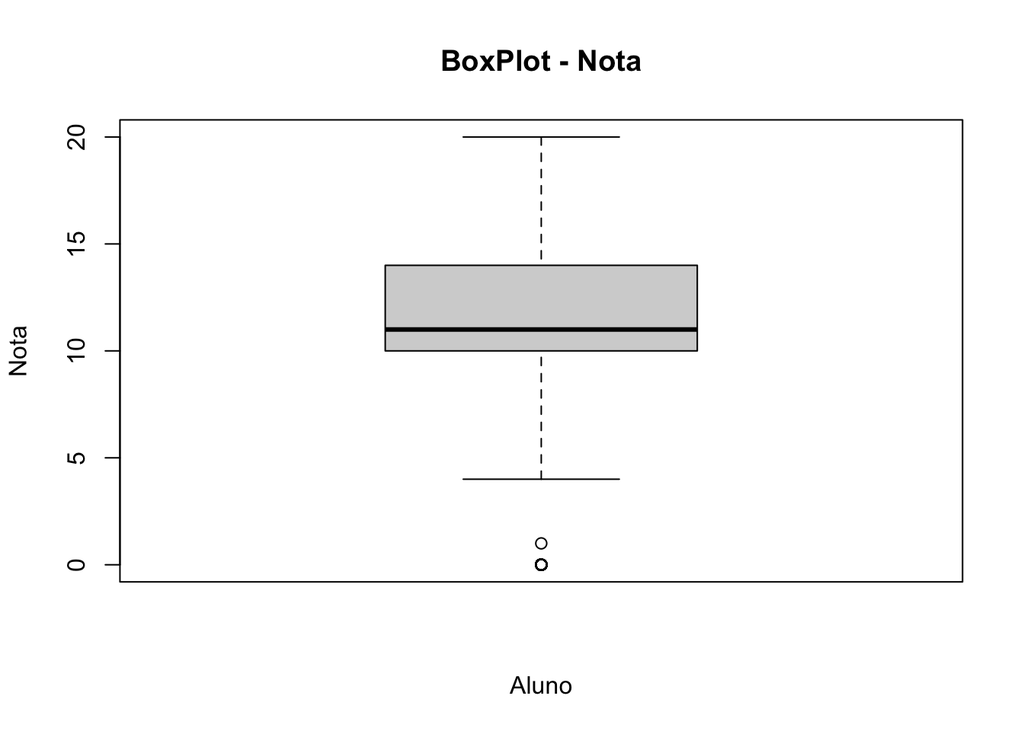

### 2.1.2 Idade

**Variância**

```
## Variância das Idades: 1.538
```

**Desvio Padrão**

```
## Desvio Padrão das Idades: 1.24
```

**Coeficiente de Variação**

```
## Coeficiente de Variação das Idades: 7.41 %
```

O BoxPlot da idade ilustra bem a variabilidade dos dados.

É visível que a distribuição das Notas x Idade, gráfico de dispersão, apresenta uma concentração maior entre os alunos de 15 a 18 anos. Isso pode ser confirmado também no histograma de Idade.

#### 2.1.2.1 BoxPlot

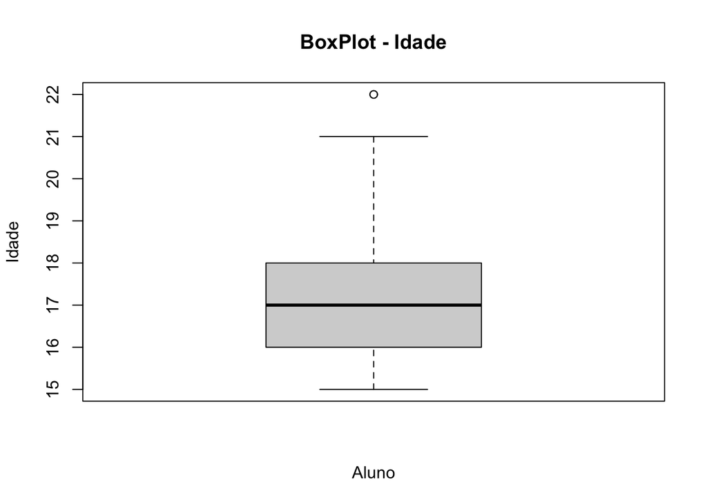

#### 2.1.2.2 Histograma

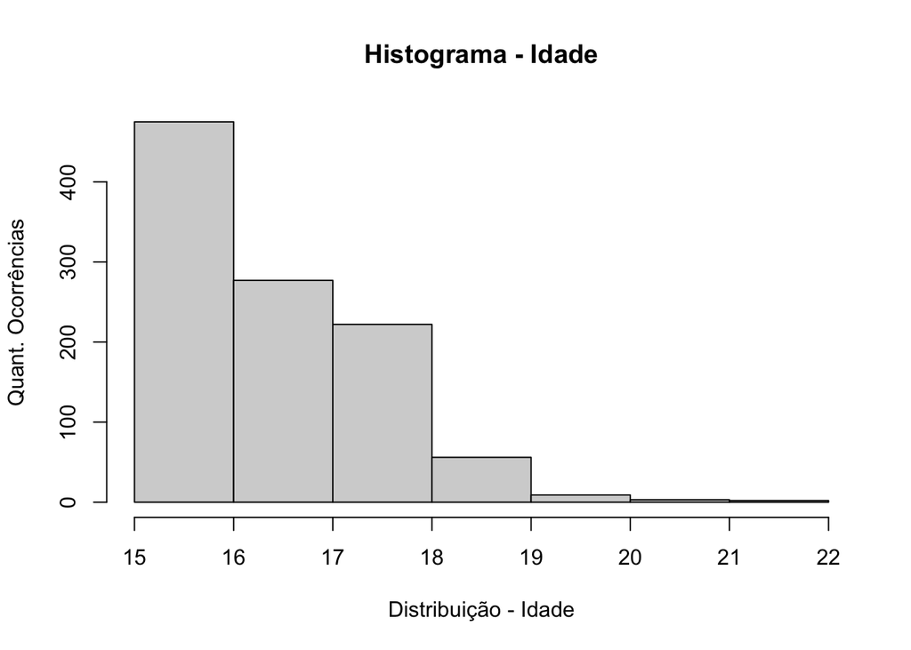

#### 2.1.2.3 Dispersão

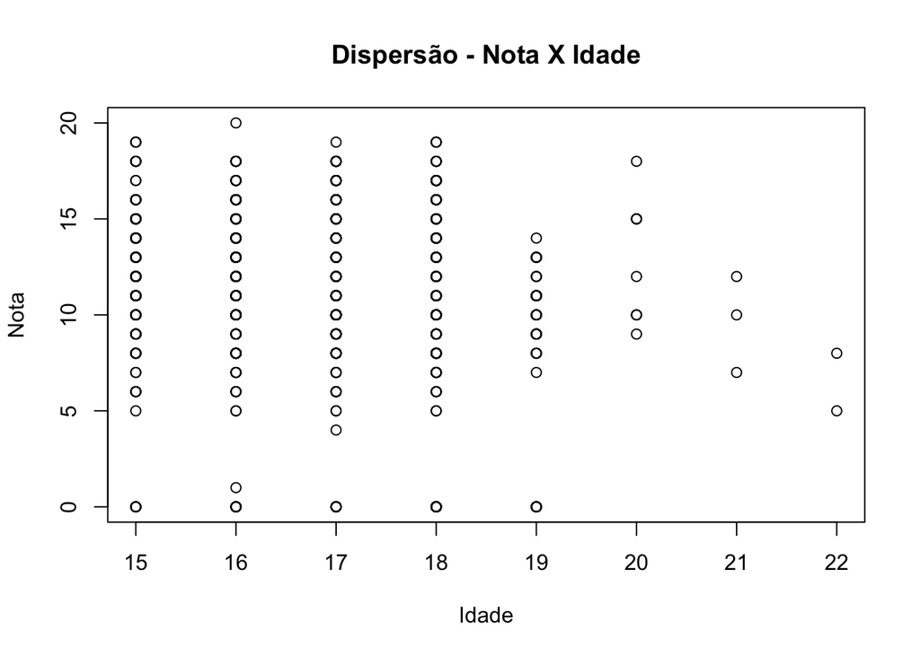

### 2.1.3 Reprovação

**Variância**

```
## Variância das Reprovações: 0.431
```

**Desvio Padrão**

```
## Desvio Padrão das Reprovações: 0.656
```

**Coeficiente de Variação**

```
## Coeficiente de Variação das Reprovações: 248.19 %
```

O Histograma de Reprovação mostra que a maioria dos alunos tem menos de 1 reprovação. Tanto que o BoxPlot trás valores como 1, 2 e 3 como outlier.

#### 2.1.3.1 BoxPlot

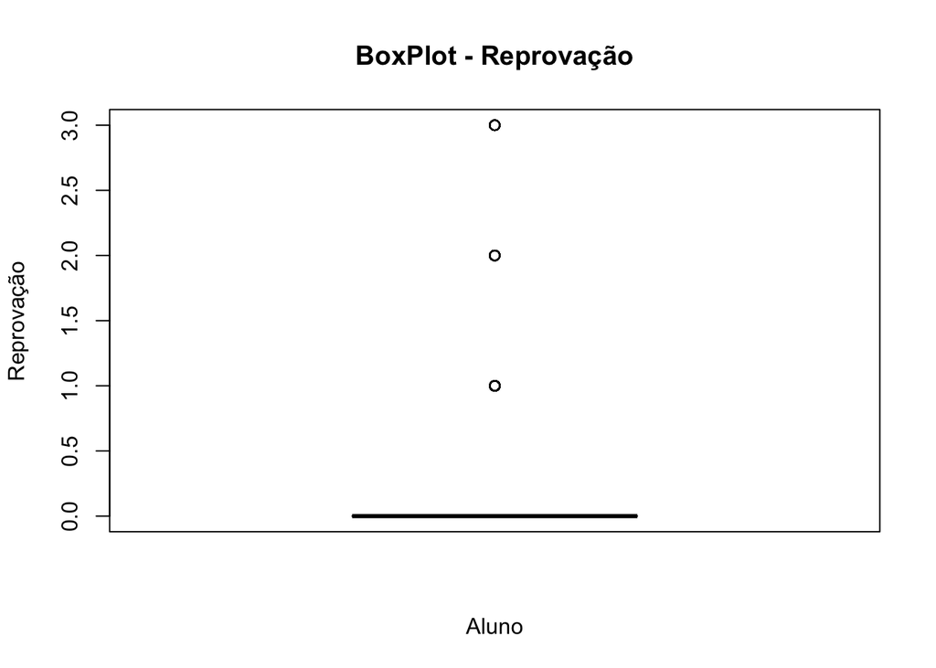

#### 2.1.3.2 Histograma

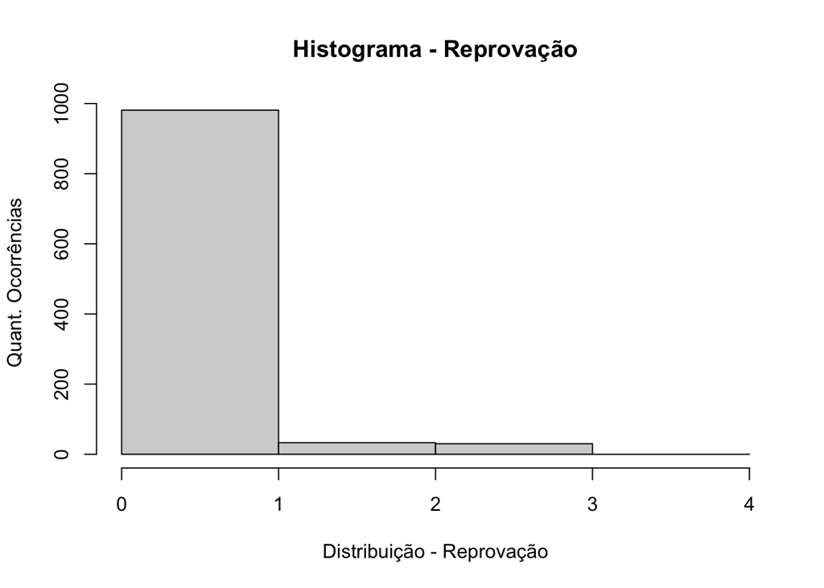

#### 2.1.3.3 Dispersão

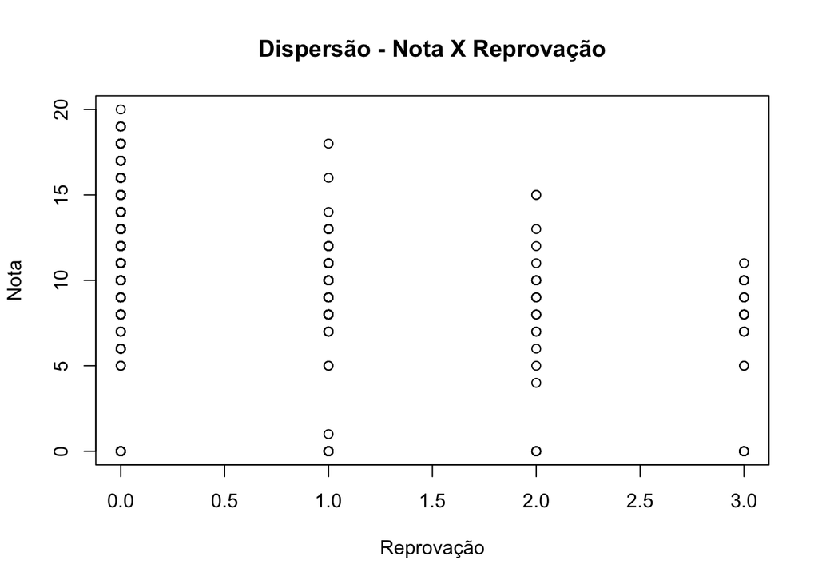

### 2.1.4 Faltas

**Variância**

```
## Variância das Faltas: 38.564
```

**Desvio Padrão**

```
## Desvio Padrão das Faltas: 6.21
```

**Coeficiente de Variação**

```
## Coeficiente de Variação das Faltas: 140.03 %
```

Observando o gráfico de dispersão, podemos constatar que a maiorias dos alunos apresentam menos de 20 faltas, visto que existe uma concentração no lado esquerdo do gráfico.

#### 2.1.4.1 BoxPlot

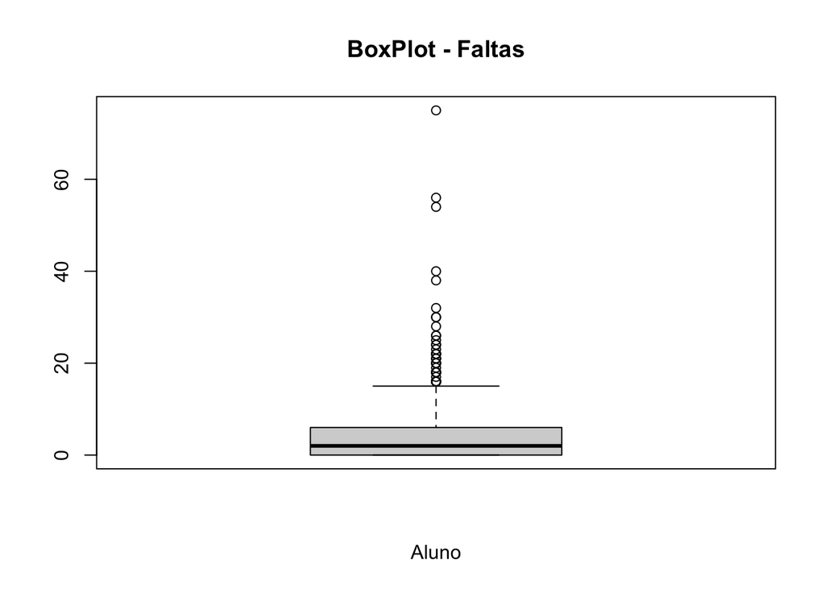

#### 2.1.4.2 Histograma

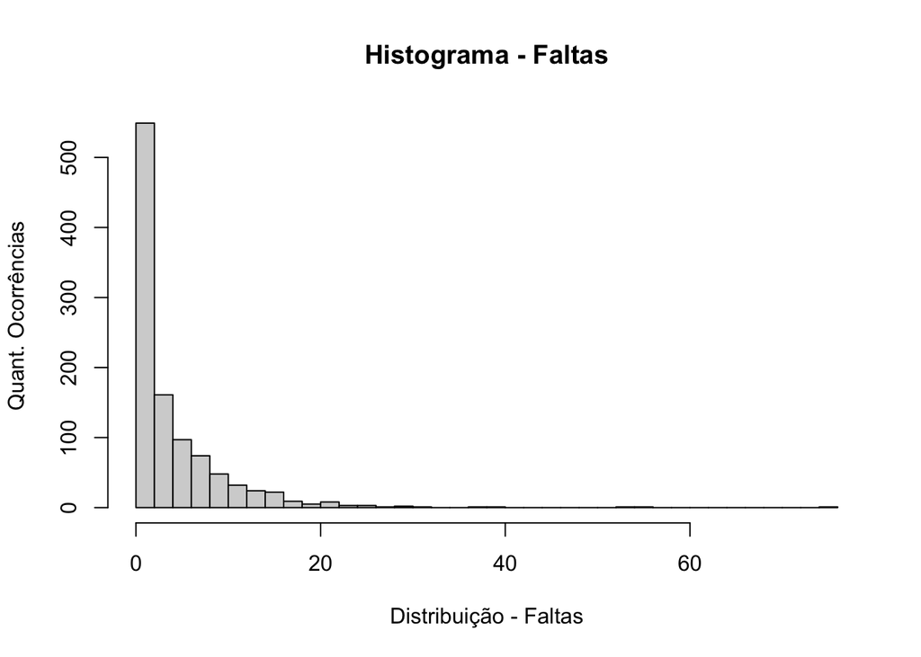

#### 2.1.4.3 Dispersão

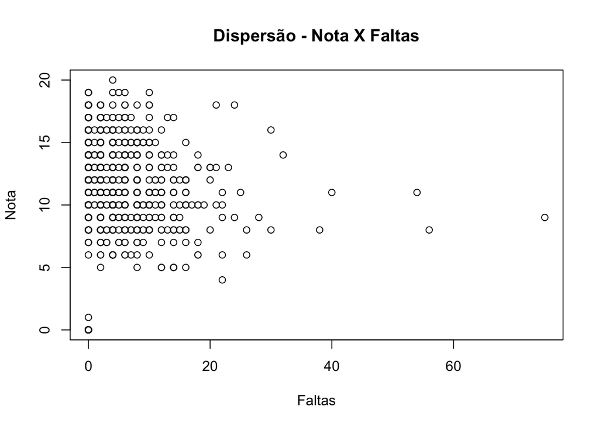

# 3 Correlação das Variáveis

Todas a variáveis apresentam correlação negativa e no mínimo fraca. A variável independete que melhor apresentou correlação com a **Nota(G3)** foi **Reprovações(failures) -0.38** .

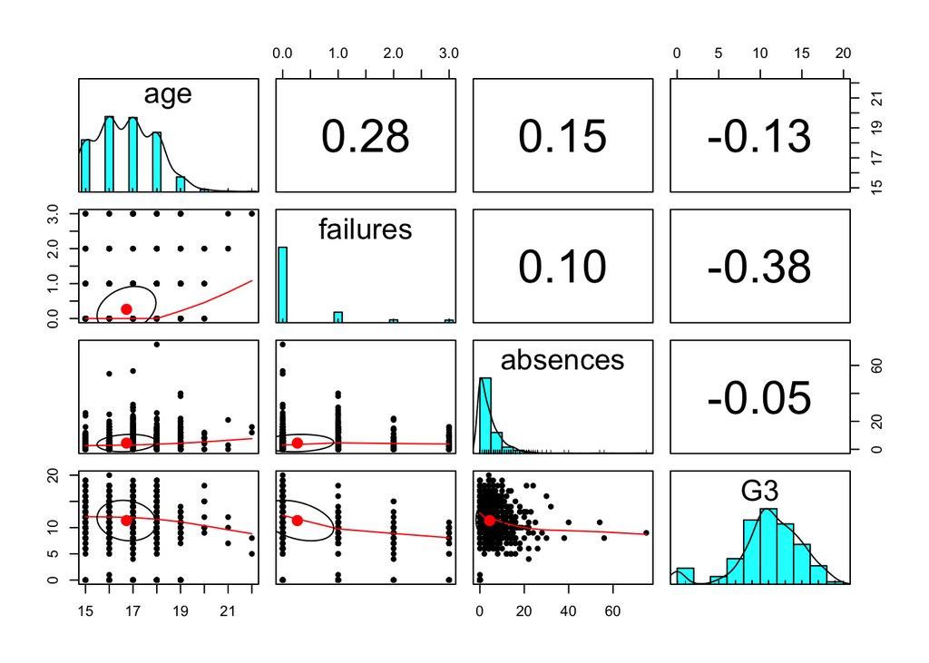

# 4 Regressões Lineares - Individualizadas

Para termos um modelo de regressão linear, precisamos atender alguns pressupostos:  
1. Variâncias Homogêneas (Homocedasticidade);  
2. A distribuição deve ser Normal;  
3. Não existir Outlier Extremos.

Ao analisar os gráficos de *“Residuals vs Fitted”*, podemos constatar que os resíduos de todas as variáveis independetes não estão bem distribuídos, caracterizando assim heterocesticidade em todos os modelos.  
Quando verificamos os gráficos de *“Normal Q-Q”* observamos que em todos os modelos tiveramos vários resíduos padronizados fora da diagonal de normalidade, o que nos leva a considerar que parte desses resíduos não apresentam uma distribuição Normal.

> Assim, podemos afirmar que **o modelo de Regressão Linear não é o mais adequado para esses dados.** Mas para fins acadêmicos, iremos dar continuidade na análise do modelo de Regressão Linear Múltipla.

## 4.1 Modelo Nota x Idade

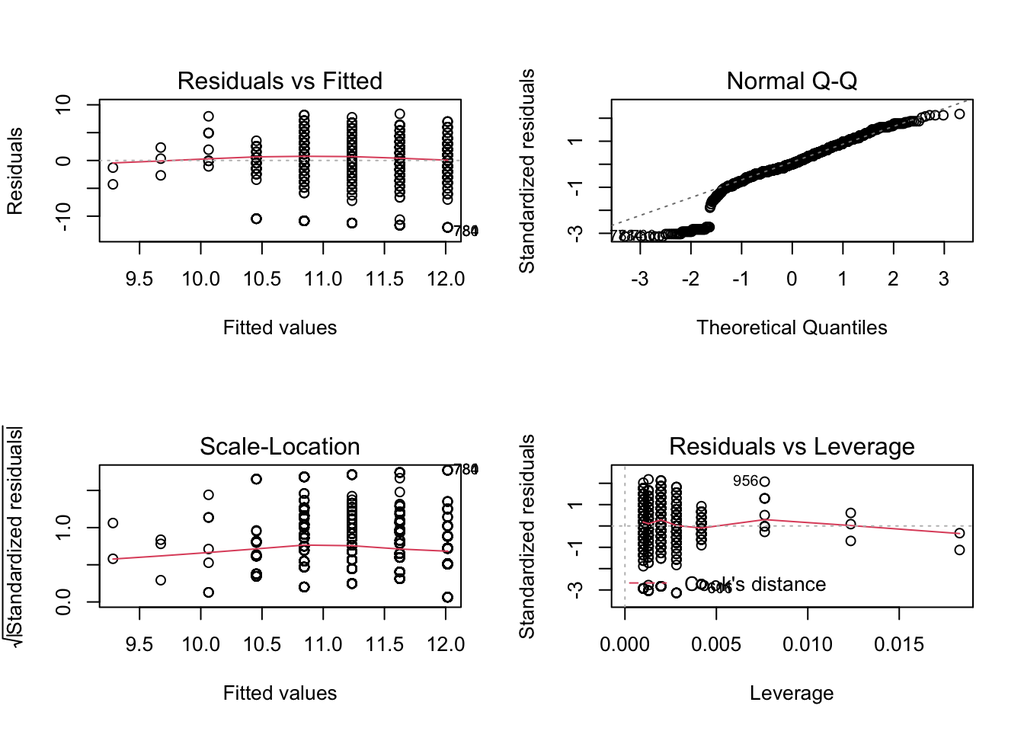

## 4.2 Modelo Nota x Reprovação

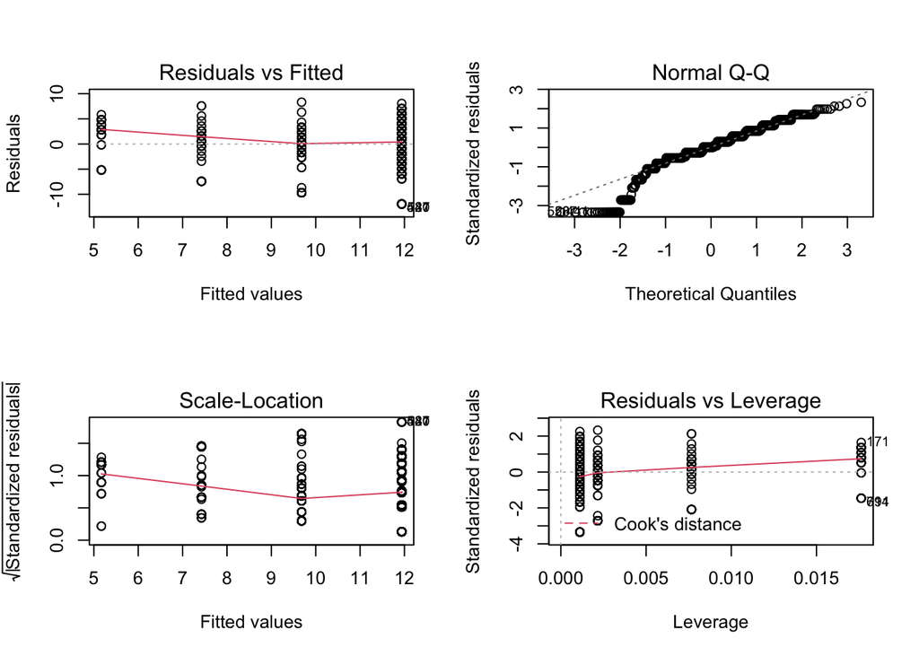

## 4.3 Modelo Nota x Faltas

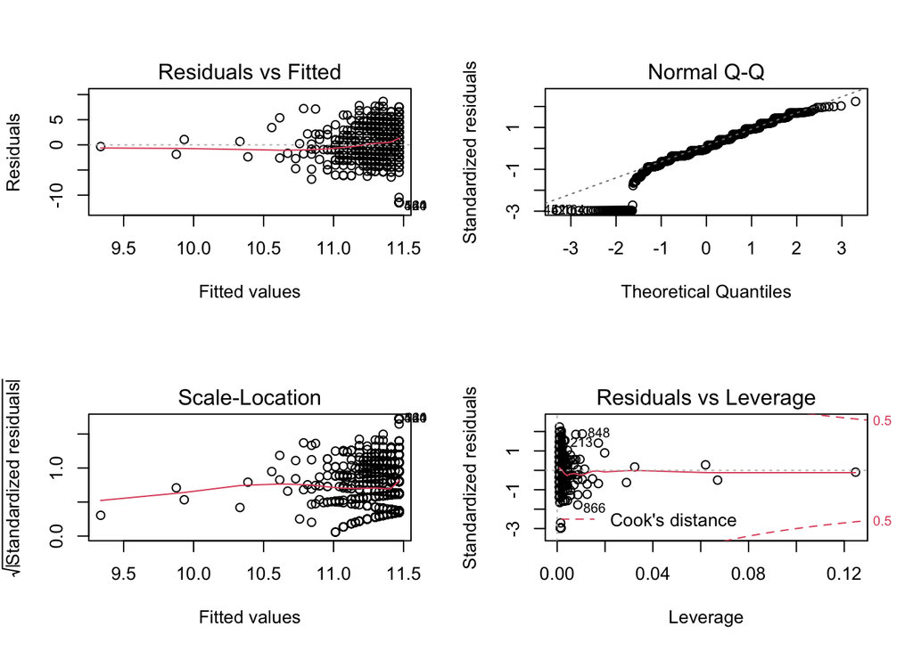

# 5 Formulação do Modelo Regressão Linear Mútipla

Admitindo que os os modelos de regressão linear são adequados para os dados. Queremos identificar se o modelo de regressão linear múltipla com todas as variáveis é melhor que o modelo de regressão linear da variável de maior corretação (Notas x Reprovação) com nível de significância $\alpha$ de 5%.
Temos assim, as seguintes hipóteses:
$$h_0: MAE_a \le MAE_b$$
$$h_1: MAE_a > MAE_b$$
Onde:
- $MAE_a$ é o Erro Médio Absolutos do modelo com a variável de maior correlação (*Nota x Reprovação*);
- $MAE_b$ é o Erro Médio Absolutos do modelo com todas as variáveis (*Nota x Idade + Reprovação + Faltas*).

# 6 Método de Monte Carlo

Iremos realizar o particionamento dos dados em treinamento e teste utilizando o método de Hold Out. Consideraremos que a amostra de treino terá $\frac{2}{3}$ do tamanho do nossos dados e logo o teste terá $\frac{1}{3}$ do tamanho. E iremos realizar as iterações na ordem de $\frac{1}{3}$ do tamanho dos nossos dados.

```r
ErrorAbs_All = ErrorAbs_Fail = c(0)

MC = round(dim(df)[1]/3, 0)

for(i in 1:MC){

  ind= createDataPartition(df$G3, p=2/3, list=FALSE)

  train.data <- df[ind,]
  test.data <- df[-ind,]

  reg_All <- lm(G3 ~ age + absences + failures, train.data)
  reg_Fail <- lm(G3 ~ failures, train.data)

  pred_All <-predict(reg_All, test.data)
  pred_Fail <- predict(reg_Fail, test.data)

  ErrorAbs_All[i] <- MAE(pred_All, test.data$G3)
  ErrorAbs_Fail[i] <- MAE(pred_Fail, test.data$G3)
  }
```

# 7 Resultados

Após realizar o cálculo do Erro Médio Absoludo (*MAE*) para os modelos, N vezes (de acordo com o número de iterações realizadas no modelo de Monte Carlo - Método Hold Out) chegamos aos seguintes resultados:

## 7.1 Teste de Normalidade

### 7.1.1 Histogramas

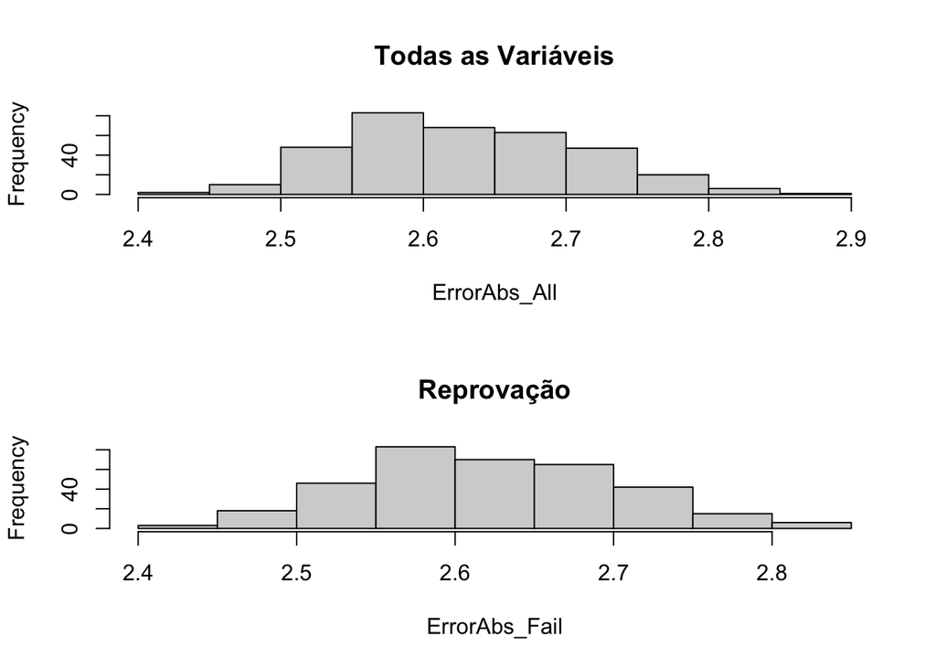

### 7.1.2 Shapiro Test

```
## Valor de p no Shapiro Test para Todas as Variáveis  - 0.006
```

```
## Valor de p no Shapiro Test para Reprovação - 0.019
```

## 7.2 Student T Test

Quanto menor for o P-Value melhor para rejeitar $h_0$.

```
## P-Value = 0.1
```

```
## t = 1.285
```

```
## df = 693.984
```

> Dado que o P-Value (10%) foi superior ao nível de significância ($\alpha = 5\%$) determinado a priori. Não podemos rejitar a hipótese nula e consequentemente não podemos afirmar nada a respeito da hipótese alternativa.
[^1]: [Base de Dados - performance de Estudantes](https://archive.ics.uci.edu/ml/datasets/Student+Performance)
[^2]: [Repositório da UC Irvine Machine Learnig](https://archive.ics.uci.edu/ml/index.php)